# Trust in Science Analysis Notebook

Load Data

```r
results <- read.csv("data_clean_june30.csv")

# trust in data is the column: bar-data_6
# trust in vis is the column: bar-vis_6
```

Converting covariates to factors

```r
results$Gender <- as.factor(results$Gender)
results$Education <- as.factor(results$Education)
results$Parents_education <- as.factor(results$Parents_education)
results$Language <- as.factor(results$Language)
results$Ethnicity <- as.factor(results$Ethnicity)
results$Income <- as.factor(results$Income)
results$Religion <- as.factor(results$Religion)
```

Trust in Vis

```r
# results$isCovidData <- factor(results$isCovidData, levels = c(0, 1),
#                   labels = c("Crop Data", "Covid Data"))
```

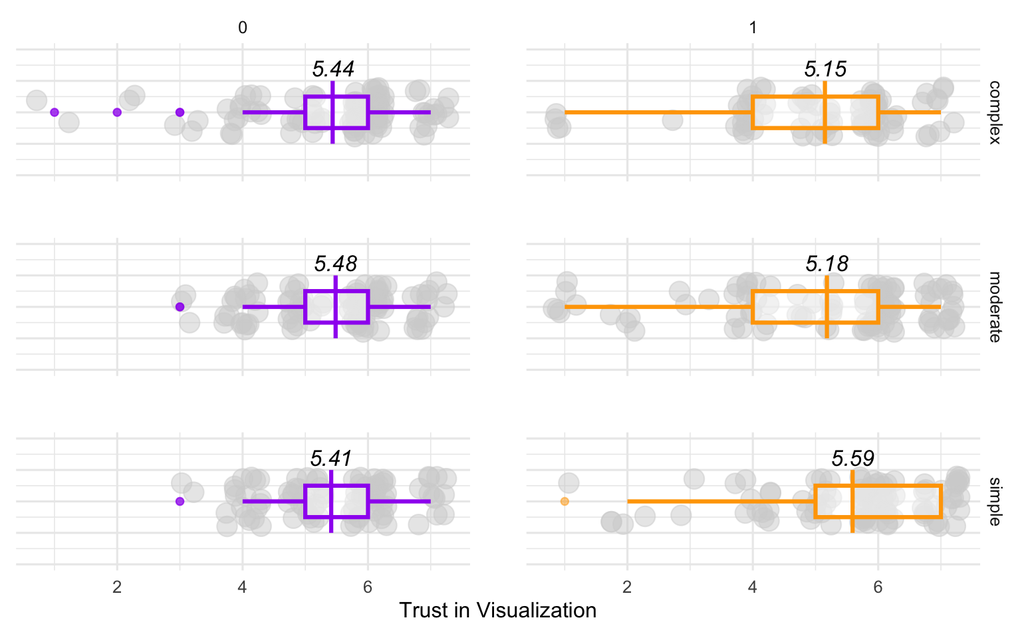

```r
MinMeanSEMMax <- function(x) {
  v <- c(min(x), mean(x) - sd(x)/sqrt(length(x)), mean(x), mean(x) + sd(x)/sqrt(length(x)), max(x))
  names(v) <- c("ymin", "lower", "middle", "upper", "ymax")
  v
}

results %>%
  # group_by(complexity, isCovidData) %>%
  ggplot(aes( x = vis.trust_6, y = 0, cex=1.5, colour = as.factor(isCovidData))) +
  scale_color_manual(values = c("purple", "orange")) +
  ylim(-0.5, 0.5) +
  geom_jitter(data = results, width = 0.3, height = 0.2, color = "light gray", alpha = 0.5) +
  #stat_summary(fun.data=MinMeanSEMMax, geom="boxplot", colour="red") +

  geom_boxplot(lwd = 1, fatten = NULL, width = 0.25, alpha = 0.5) +

  geom_segment(data = results %>%
                group_by(complexity, isCovidData) %>%
                summarize(n = n(),
                           mean = mean(vis.trust_6),
            se = sd(vis.trust_6)/sqrt(n)),
              aes(x = mean, xend = mean, y = -.25, yend = .25,  colour = as.factor(isCovidData)), size = 1) +
        # stat_summary(fun.data = "mean_cl_boot", colour = "red", size = 0.5, position = position_nudge(x=0.25, y=0), alpha=0.5) +

  geom_text( data = results %>%
                group_by(complexity, isCovidData) %>%
                summarize(n = n(),
                           mean = round(mean(vis.trust_6),digits=2),
            se = round(sd(data.trust_6)/sqrt(n),digits=2),
                          vis.trust_6 = mean(vis.trust_6)),
            # aes(label = paste(mean, "[",mean-se,",",mean+se,"]"), x = 6.2, y = 0.43, fontface = 3), size=3, colour = "black")+
              aes(label = paste(mean), x = mean, y = .35, fontface = 3), size=4, colour = "black")+

  facet_grid(complexity ~ isCovidData) +
  xlab("Trust in Visualization") +
  theme_minimal() +
  theme(panel.spacing = unit(2, "lines"),
        legend.position = "none",
        axis.text.y = element_blank(),
        axis.title.y = element_blank(),
        axis.ticks.y = element_blank())
```

```r
#ggsave(paste("complexity_dataType_interaction.pdf", sep=""))
```

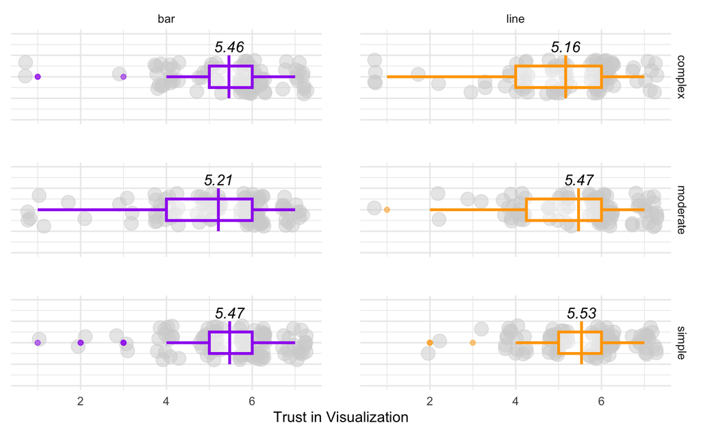

```r
MinMeanSEMMax <- function(x) {
  v <- c(min(x), mean(x) - sd(x)/sqrt(length(x)), mean(x), mean(x) + sd(x)/sqrt(length(x)), max(x))
  names(v) <- c("ymin", "lower", "middle", "upper", "ymax")
  v
}

results %>%
  # group_by(complexity, isCovidData) %>%
  ggplot(aes( x = vis.trust_6, y = 0, cex=1.5, colour = chartType)) +
  scale_color_manual(values = c("purple", "orange")) +
  ylim(-0.5, 0.5) +
  geom_jitter(data = results, width = 0.3, height = 0.2, color = "light gray", alpha = 0.5) +
  #stat_summary(fun.data=MinMeanSEMMax, geom="boxplot", colour="red") +

  geom_boxplot(lwd = 1, fatten = NULL, width = 0.25, alpha = 0.5) +

  geom_segment(data = results %>%
                group_by(complexity, chartType) %>%
                summarize(n = n(),
                           mean = mean(vis.trust_6),
            se = sd(vis.trust_6)/sqrt(n)),
              aes(x = mean, xend = mean, y = -.25, yend = .25,  colour = chartType), size = 1) +
        # stat_summary(fun.data = "mean_cl_boot", colour = "red", size = 0.5, position = position_nudge(x=0.25, y=0), alpha=0.5) +

  geom_text( data = results %>%
                group_by(complexity, chartType) %>%
                summarize(n = n(),
                           mean = round(mean(vis.trust_6),digits=2),
            se = round(sd(data.trust_6)/sqrt(n),digits=2),
                          vis.trust_6 = mean(vis.trust_6)),
            # aes(label = paste(mean, "[",mean-se,",",mean+se,"]"), x = 6.2, y = 0.43, fontface = 3), size=3, colour = "black")+
              aes(label = paste(mean), x = mean, y = .35, fontface = 3), size=4, colour = "black")+

  facet_grid(complexity ~ chartType) +
  xlab("Trust in Visualization") +
  theme_minimal() +
  theme(panel.spacing = unit(2, "lines"),
        legend.position = "none",
        axis.text.y = element_blank(),
        axis.title.y = element_blank(),
        axis.ticks.y = element_blank())
ggsave(paste("complexity_chartType_interaction.pdf", sep=""))
```

```r
results %>%
  group_by(complexity, isCovidData) %>%
  summarize(n = n(),
            mean = mean(vis.trust_6),
            se = sd(vis.trust_6)/sqrt(n),
            n = n)
```

```r
# results$isCovidData <- factor(results$isCovidData, levels = c(0, 1),
#                   labels = c("Crop Data", "Covid Data"))

results %>%
  ggplot(aes(x = data.trust_6, y = 0)) +
  # scale_color_manual(values = c("purple", "orange")) +
  ylim(-0.5, 0.5) +
  geom_jitter(data = results, width = 0.25, height = 0.2, color = "light gray", alpha = 0.5) +
  geom_boxplot(lwd = 1, fatten = NULL, width = 0.25, alpha = 0.5, color = "salmon") +
  # labs(title = "Trust in data") +


   geom_segment(data = results %>%
                group_by(complexity) %>%
                summarize(n = n(),
                           mean = mean(data.trust_6),
            se = sd(data.trust_6)/sqrt(n)),
              aes(x = mean, xend = mean, y = -.25, yend = .25,  colour ="salmon"), size = 1) +


  geom_text( data = results %>%
                group_by(complexity) %>%
                summarize(n = n(),
                           mean = round(mean(data.trust_6),digits=2),
            se = round(sd(data.trust_6)/sqrt(n),digits=2),
                          dadta.trust_6 = mean(data.trust_6)),
            # aes(label = paste(mean, "[",mean-se,",",mean+se,"]"), x = 6.2, y = 0.43, fontface = 3), size=3, colour = "black")+
              aes(label = paste(mean), x = mean, y = .35, fontface = 3), size=4, colour = "black")+



  facet_grid(rows = vars(complexity)) +
  xlab("Trust in Data") +
  theme_minimal() +
  theme(panel.spacing = unit(2, "lines"),
        legend.position = "none",
        axis.text.y = element_blank(),
        axis.title.y = element_blank(),
        axis.ticks.y = element_blank())

#ggsave(paste("complexity_interaction.pdf", sep=""))
```

```r
results %>%
 filter(isCovidData ==0 ) %>%
  group_by(complexity) %>%
  summarize(n = n(),
            mean = mean(vis.trust_6),
            se = sd(vis.trust_6)/sqrt(n),
            n = n)
```

```r
model <- lm(formula = vis.trust_6 ~ complexity  * as.factor(isCovidData) * chartType + Age + Gender + State_1 + Education + Parents_education + Language + Ethnicity + Income + Religion + trust.in.science_7 + need_for_cognition + interpersonal.trust_1 ,
            data = results)
anova(model)
```

```
Analysis of Variance Table

Response: vis.trust_6
                                             Df Sum Sq Mean Sq  F value    Pr(>F)
complexity                                    2   4.45   2.226   1.7237  0.179624
as.factor(isCovidData)                        1   2.74   2.736   2.1181  0.146282
chartType                                     1   0.02   0.020   0.0153  0.901530
Age                                           1   9.31   9.308   7.2072  0.007537 **
Gender                                        3   7.63   2.544   1.9699  0.117759
State_1                                      46 127.87   2.780   2.1523 4.266e-05 ***
Education                                     9  33.27   3.697   2.8621  0.002729 **
Parents_education                             2   1.57   0.787   0.6095  0.544099
Language                                      3   3.04   1.013   0.7841  0.503252
Ethnicity                                     8  16.99   2.124   1.6446  0.110101
Income                                       18  29.11   1.617   1.2521  0.215752
Religion                                      4  14.44   3.610   2.7951  0.025844 *
trust.in.science_7                            1 138.52 138.515 107.2476 < 2.2e-16 ***
need_for_cognition                            1   6.54   6.541   5.0644  0.024919 *
interpersonal.trust_1                         1   6.90   6.900   5.3428  0.021273 *
complexity:as.factor(isCovidData)             2   3.13   1.564   1.2108  0.298943
complexity:chartType                          2   3.36   1.680   1.3006  0.273429
as.factor(isCovidData):chartType              1   0.64   0.639   0.4945  0.482305
complexity:as.factor(isCovidData):chartType   2   0.35   0.175   0.1353  0.873503
Residuals                                   437 564.41   1.292
---
Signif. codes:  0 ‘***’ 0.001 ‘**’ 0.01 ‘*’ 0.05 ‘.’ 0.1 ‘ ’ 1
```

```r
model <- lm(formula = vis.trust_6 ~ complexity  * as.factor(isCovidData) + chartType + Age + Gender + State_1 + Education + Parents_education + Language + Ethnicity + Income + Religion + trust.in.science_7 + need_for_cognition + interpersonal.trust_1 ,
            data = results%>% filter(complexity !='moderatex'))
anova(model)
```

```r
model <- lm(formula = vis.trust_6 ~ complexity * as.factor(isCovidData) + chartType + trust.in.science_7 + need_for_cognition + interpersonal.trust_1 ,
            data = results)
anova(model)
```

```r
model <- lm(formula = vis.trust_6 ~ complexity * as.factor(isCovidData) * chartType  + Age + Gender + State_1 + Income + Education + Parents_education + Language + Ethnicity  + Religion + trust.in.science_7 + need_for_cognition + interpersonal.trust_1 ,
            data = results)
anova(model)
```

```
Analysis of Variance Table

Response: vis.trust_6
                                             Df Sum Sq Mean Sq  F value    Pr(>F)
complexity                                    2   4.45   2.226   1.7237  0.179624
as.factor(isCovidData)                        1   2.74   2.736   2.1181  0.146282
chartType                                     1   0.02   0.020   0.0153  0.901530
Age                                           1   9.31   9.308   7.2072  0.007537 **
Gender                                        3   7.63   2.544   1.9699  0.117759
State_1                                      46 127.87   2.780   2.1523 4.266e-05 ***
Income                                       18  36.70   2.039   1.5788  0.061567 .
Education                                     9  27.94   3.105   2.4040  0.011443 *
Parents_education                             2   0.91   0.455   0.3526  0.703060
Language                                      3   2.25   0.749   0.5797  0.628627
Ethnicity                                     8  16.18   2.022   1.5659  0.132820
Religion                                      4  14.44   3.610   2.7951  0.025844 *
trust.in.science_7                            1 138.52 138.515 107.2476 < 2.2e-16 ***
need_for_cognition                            1   6.54   6.541   5.0644  0.024919 *
interpersonal.trust_1                         1   6.90   6.900   5.3428  0.021273 *
complexity:as.factor(isCovidData)             2   3.13   1.564   1.2108  0.298943
complexity:chartType                          2   3.36   1.680   1.3006  0.273429
as.factor(isCovidData):chartType              1   0.64   0.639   0.4945  0.482305
complexity:as.factor(isCovidData):chartType   2   0.35   0.175   0.1353  0.873503
Residuals                                   437 564.41   1.292
---
Signif. codes:  0 ‘***’ 0.001 ‘**’ 0.01 ‘*’ 0.05 ‘.’ 0.1 ‘ ’ 1
```

```r
model<- manova( cbind(vis.trust_6,vis.trust_1,vis.trust_2,vis.trust_3,vis.trust_4,vis.trust_5,affect.science_1,affect.clarity_1,affect.aesthetic_1) ~ complexity  * as.factor(isCovidData) * chartType  + Age + Gender + State_1 + Education + Parents_education + Language + Ethnicity + Income + Religion + trust.in.science_7 + need_for_cognition + interpersonal.trust_1 ,
               data = results)

summary(model)
```

```
                                             Df  Pillai approx F num Df den Df    Pr(>F)
complexity                                    2 0.15735   4.0798     18    860 2.919e-08 ***
as.factor(isCovidData)                        1 0.14918   8.3574      9    429 1.621e-11 ***
chartType                                     1 0.03225   1.5884      9    429  0.116163
Age                                           1 0.03849   1.9079      9    429  0.049143 *
Gender                                        3 0.05602   0.9113     27   1293  0.596349
State_1                                      46 0.97283   1.1513    414   3933  0.023586 *
Education                                     9 0.23390   1.2956     81   3933  0.039962 *
Parents_education                             2 0.03526   0.8574     18    860  0.631723
Language                                      3 0.04049   0.6553     27   1293  0.911225
Ethnicity                                     8 0.15874   0.9807     72   3488  0.524493
Income                                       18 0.37955   1.0689    162   3933  0.264814
Religion                                      4 0.10146   1.2492     36   1728  0.148400
trust.in.science_7                            1 0.21604  13.1355      9    429 < 2.2e-16 ***
need_for_cognition                            1 0.05685   2.8732      9    429  0.002644 **
interpersonal.trust_1                         1 0.04369   2.1778      9    429  0.022599 *
complexity:as.factor(isCovidData)             2 0.03055   0.7410     18    860  0.769808
complexity:chartType                          2 0.07113   1.7620     18    860  0.025638 *
as.factor(isCovidData):chartType              1 0.01981   0.9633      9    429  0.469901
complexity:as.factor(isCovidData):chartType   2 0.02939   0.7127     18    860  0.800338
Residuals                                   437
---
Signif. codes:  0 ‘***’ 0.001 ‘**’ 0.01 ‘*’ 0.05 ‘.’ 0.1 ‘ ’ 1
```

```r
eta_squared(model)
```

```
# Effect Size for ANOVA (Type I)

Parameter                                   | Eta2 (partial) |       95% CI
---------------------------------------------------------------------------
complexity                                  |           0.08 | [0.04, 1.00]
as.factor(isCovidData)                      |           0.15 | [0.09, 1.00]
chartType                                   |           0.03 | [0.00, 1.00]
Age                                         |           0.04 | [0.00, 1.00]
Gender                                      |           0.02 | [0.00, 1.00]
State_1                                     |           0.11 | [0.12, 1.00]
Education                                   |           0.03 | [0.00, 1.00]
Parents_education                           |           0.02 | [0.00, 1.00]
Language                                    |           0.01 | [0.00, 1.00]
Ethnicity                                   |           0.02 | [0.00, 1.00]
Income                                      |           0.04 | [0.00, 1.00]
Religion                                    |           0.03 | [0.00, 1.00]
trust.in.science_7                          |           0.22 | [0.15, 1.00]
need_for_cognition                          |           0.06 | [0.01, 1.00]
interpersonal.trust_1                       |           0.04 | [0.00, 1.00]
complexity:as.factor(isCovidData)           |           0.02 | [0.00, 1.00]
complexity:chartType                        |           0.04 | [0.00, 1.00]
as.factor(isCovidData):chartType            |           0.02 | [0.00, 1.00]
complexity:as.factor(isCovidData):chartType |           0.01 | [0.00, 1.00]

- One-sided CIs: upper bound fixed at [1.00].
```

```r
summary.aov(model)
```

```
 Response vis.trust_6 :
                                             Df Sum Sq Mean Sq  F value    Pr(>F)
complexity                                    2   4.45   2.226   1.7237  0.179624
as.factor(isCovidData)                        1   2.74   2.736   2.1181  0.146282
chartType                                     1   0.02   0.020   0.0153  0.901530
Age                                           1   9.31   9.308   7.2072  0.007537 **
Gender                                        3   7.63   2.544   1.9699  0.117759
State_1                                      46 127.87   2.780   2.1523 4.266e-05 ***
Education                                     9  33.27   3.697   2.8621  0.002729 **
Parents_education                             2   1.57   0.787   0.6095  0.544099
Language                                      3   3.04   1.013   0.7841  0.503252
Ethnicity                                     8  16.99   2.124   1.6446  0.110101
Income                                       18  29.11   1.617   1.2521  0.215752
Religion                                      4  14.44   3.610   2.7951  0.025844 *
trust.in.science_7                            1 138.52 138.515 107.2476 < 2.2e-16 ***
need_for_cognition                            1   6.54   6.541   5.0644  0.024919 *
interpersonal.trust_1                         1   6.90   6.900   5.3428  0.021273 *
complexity:as.factor(isCovidData)             2   3.13   1.564   1.2108  0.298943
complexity:chartType                          2   3.36   1.680   1.3006  0.273429
as.factor(isCovidData):chartType              1   0.64   0.639   0.4945  0.482305
complexity:as.factor(isCovidData):chartType   2   0.35   0.175   0.1353  0.873503
Residuals                                   437 564.41   1.292
---
Signif. codes:  0 ‘***’ 0.001 ‘**’ 0.01 ‘*’ 0.05 ‘.’ 0.1 ‘ ’ 1

 Response vis.trust_1 :
                                             Df Sum Sq Mean Sq F value    Pr(>F)
complexity                                    2   3.28   1.639  0.9045  0.405508
as.factor(isCovidData)                        1   6.62   6.616  3.6503  0.056715 .
chartType                                     1   0.43   0.425  0.2346  0.628354
Age                                           1   7.62   7.623  4.2062  0.040873 *
Gender                                        3   3.43   1.142  0.6302  0.595862
State_1                                      46 124.61   2.709  1.4946  0.023238 *
Education                                     9   4.70   0.522  0.2879  0.977939
Parents_education                             2   3.90   1.949  1.0755  0.342034
Language                                      3   4.53   1.509  0.8327  0.476399
Ethnicity                                     8  15.84   1.980  1.0922  0.367304
Income                                       18  26.77   1.487  0.8206  0.676327
Religion                                      4   5.83   1.458  0.8047  0.522603
trust.in.science_7                            1  54.39  54.386 30.0075 7.279e-08 ***
```

[output cut: 171 more lines]

```
Ethnicity                                     8   3551   443.9  0.8426 0.56546
Income                                       18   4902   272.3  0.5170 0.95040
Religion                                      4   1972   493.0  0.9358 0.44295
trust.in.science_7                            1   3167  3167.1  6.0117 0.01460 *
need_for_cognition                            1   2194  2194.0  4.1647 0.04188 *
interpersonal.trust_1                         1   2577  2577.2  4.8921 0.02750 *
complexity:as.factor(isCovidData)             2    645   322.6  0.6123 0.54256
complexity:chartType                          2   2044  1022.2  1.9404 0.14488
as.factor(isCovidData):chartType              1   1504  1504.5  2.8558 0.09176 .
complexity:as.factor(isCovidData):chartType   2     50    25.1  0.0476 0.95355
Residuals                                   437 230219   526.8
---
Signif. codes:  0 ‘***’ 0.001 ‘**’ 0.01 ‘*’ 0.05 ‘.’ 0.1 ‘ ’ 1

3 observations deleted due to missingness
```

```r
model<- manova( cbind(data.trust_6,data.trust_1,data.trust_2,data.trust_3,data.trust_4,data.trust_5) ~ complexity  * as.factor(isCovidData) * chartType  + Age + Gender + State_1 + Education + Parents_education + Language + Ethnicity + Income + Religion + trust.in.science_7 + need_for_cognition + interpersonal.trust_1 ,
               data = results)

anova(model)
```

```
Analysis of Variance Table

                                             Df  Pillai approx F num Df den Df    Pr(>F)
(Intercept)                                   1 0.97922   3392.6      6    432 < 2.2e-16 ***
complexity                                    2 0.06719      2.5     12    866  0.003029 **
as.factor(isCovidData)                        1 0.12758     10.5      6    432 6.446e-11 ***
chartType                                     1 0.01608      1.2      6    432  0.317789
Age                                           1 0.03575      2.7      6    432  0.014868 *
Gender                                        3 0.06592      1.6     18   1302  0.047127 *
State_1                                      46 0.69976      1.3    276   2622  0.004228 **
Education                                     9 0.15077      1.3     54   2622  0.104194
Parents_education                             2 0.02989      1.1     12    866  0.360602
Language                                      3 0.05927      1.5     18   1302  0.096618 .
Ethnicity                                     8 0.09311      0.9     48   2622  0.739601
Income                                       18 0.21734      0.9    108   2622  0.728266
Religion                                      4 0.06342      1.2     24   1740  0.260746
trust.in.science_7                            1 0.21058     19.2      6    432 < 2.2e-16 ***
need_for_cognition                            1 0.04322      3.3      6    432  0.003876 **
interpersonal.trust_1                         1 0.03096      2.3      6    432  0.033816 *
complexity:as.factor(isCovidData)             2 0.02812      1.0     12    866  0.419272
complexity:chartType                          2 0.03333      1.2     12    866  0.261815
as.factor(isCovidData):chartType              1 0.02040      1.5      6    432  0.176782
complexity:as.factor(isCovidData):chartType   2 0.01151      0.4     12    866  0.957108
Residuals                                   437
---
Signif. codes:  0 ‘***’ 0.001 ‘**’ 0.01 ‘*’ 0.05 ‘.’ 0.1 ‘ ’ 1
```

```r
eta_squared(model)
```

```
# Effect Size for ANOVA (Type I)

Parameter                                   | Eta2 (partial) |       95% CI
---------------------------------------------------------------------------
complexity                                  |           0.03 | [0.01, 1.00]
as.factor(isCovidData)                      |           0.13 | [0.07, 1.00]
chartType                                   |           0.02 | [0.00, 1.00]
Age                                         |           0.04 | [0.00, 1.00]
Gender                                      |           0.02 | [0.00, 1.00]
State_1                                     |           0.12 | [0.13, 1.00]
Education                                   |           0.03 | [0.00, 1.00]
Parents_education                           |           0.01 | [0.00, 1.00]
Language                                    |           0.02 | [0.00, 1.00]
Ethnicity                                   |           0.02 | [0.00, 1.00]
Income                                      |           0.04 | [0.00, 1.00]
Religion                                    |           0.02 | [0.00, 1.00]
trust.in.science_7                          |           0.21 | [0.15, 1.00]
need_for_cognition                          |           0.04 | [0.01, 1.00]
interpersonal.trust_1                       |           0.03 | [0.00, 1.00]
complexity:as.factor(isCovidData)           |           0.01 | [0.00, 1.00]
complexity:chartType                        |           0.02 | [0.00, 1.00]
as.factor(isCovidData):chartType            |           0.02 | [0.00, 1.00]
complexity:as.factor(isCovidData):chartType |       5.75e-03 | [0.00, 1.00]

- One-sided CIs: upper bound fixed at [1.00].
```

```r
summary.aov(model)
```

```
 Response data.trust_6 :
                                             Df Sum Sq Mean Sq  F value    Pr(>F)
complexity                                    2   5.73   2.864   2.0456 0.1305443
as.factor(isCovidData)                        1   1.59   1.589   1.1346 0.2873781
chartType                                     1   0.01   0.005   0.0039 0.9504631
Age                                           1  12.15  12.148   8.6757 0.0033971 **
Gender                                        3  12.04   4.012   2.8656 0.0363516 *
State_1                                      46 154.41   3.357   2.3973 2.857e-06 ***
Education                                     9  37.77   4.197   2.9975 0.0017662 **
Parents_education                             2   3.49   1.743   1.2450 0.2889520
Language                                      3   2.88   0.960   0.6855 0.5612446
Ethnicity                                     8  14.32   1.790   1.2783 0.2527983
Income                                       18  37.39   2.077   1.4836 0.0911636 .
Religion                                      4  27.36   6.841   4.8855 0.0007307 ***
trust.in.science_7                            1 152.44 152.445 108.8744 < 2.2e-16 ***
need_for_cognition                            1   4.99   4.994   3.5665 0.0596190 .
interpersonal.trust_1                         1  13.33  13.333   9.5226 0.0021586 **
complexity:as.factor(isCovidData)             2   0.43   0.215   0.1536 0.8576451
complexity:chartType                          2   3.03   1.514   1.0816 0.3399609
as.factor(isCovidData):chartType              1   9.40   9.401   6.7144 0.0098839 **
complexity:as.factor(isCovidData):chartType   2   2.71   1.356   0.9683 0.3805454
Residuals                                   437 611.88   1.400
---
Signif. codes:  0 ‘***’ 0.001 ‘**’ 0.01 ‘*’ 0.05 ‘.’ 0.1 ‘ ’ 1

 Response data.trust_1 :
                                             Df Sum Sq Mean Sq F value    Pr(>F)
complexity                                    2   1.39   0.696  0.5744  0.563471
as.factor(isCovidData)                        1   0.41   0.408  0.3369  0.561918
chartType                                     1   1.31   1.307  1.0789  0.299510
Age                                           1   7.46   7.461  6.1609  0.013435 *
Gender                                        3   8.36   2.786  2.3007  0.076631 .
State_1                                      46  95.69   2.080  1.7179  0.003367 **
Education                                     9  18.83   2.092  1.7279  0.080452 .
Parents_education                             2   3.89   1.945  1.6061  0.201859
Language                                      3   0.96   0.322  0.2656  0.850176
Ethnicity                                     8   7.95   0.994  0.8209  0.584405
Income                                       18  34.06   1.892  1.5624  0.065976 .
Religion                                      4  19.70   4.925  4.0669  0.003008 **
trust.in.science_7                            1 103.53 103.532 85.4937 < 2.2e-16 ***
```

[output cut: 96 more lines]

```
Ethnicity                                     8  17.49  2.1860  1.2407 0.273403
Income                                       18  48.06  2.6702  1.5155 0.080086 .
Religion                                      4   4.06  1.0155  0.5764 0.679915
trust.in.science_7                            1  22.33 22.3339 12.6763 0.000411 ***
need_for_cognition                            1   6.99  6.9884  3.9665 0.047037 *
interpersonal.trust_1                         1   6.27  6.2669  3.5570 0.059958 .
complexity:as.factor(isCovidData)             2   3.30  1.6514  0.9373 0.392477
complexity:chartType                          2   1.07  0.5358  0.3041 0.737947
as.factor(isCovidData):chartType              1   0.07  0.0671  0.0381 0.845357
complexity:as.factor(isCovidData):chartType   2   1.21  0.6071  0.3446 0.708723
Residuals                                   437 769.93  1.7619
---
Signif. codes:  0 ‘***’ 0.001 ‘**’ 0.01 ‘*’ 0.05 ‘.’ 0.1 ‘ ’ 1

3 observations deleted due to missingness
```

```r
# post-hoc tests
aov(vis.trust_6 ~ complexity * as.factor(isCovidData), data = results) %>% tukey_hsd()
# effect sizes
eta_squared(aov(vis.trust_6 ~ complexity * as.factor(isCovidData) * chartType +
                  + Age + as.factor(Gender) + State_1 + as.factor(Education) + as.factor(Parents_education) + as.factor(Language) + as.factor(Ethnicity) + as.factor(Income) + as.factor(Religion) + trust.in.science_7 + need_for_cognition +
                  interpersonal.trust_1,
             data = results))
```

# Colinearity of trust in vis and trust in data

```r
colinearity_model <- lm(formula = Age ~ vis.trust_1 + vis.trust_2 + vis.trust_3 + affect.science_1 + affect.clarity_1 + affect.aesthetic_1 + vis.trust_6 + data.trust_1 + data.trust_2 + data.trust_3 + data.trust_4 + data.trust_5 + data.trust_6 + interpersonal.trust_1 + trust.in.science_7 + need_for_cognition,
            data = results)
vif(colinearity_model)
```

```r
data_frame = data.frame(results$vis.trust_1, results$vis.trust_2, results$vis.trust_3, results$affect.science_1, results$affect.clarity_1, results$affect.aesthetic_1, results$vis.trust_6, results$data.trust_1, results$data.trust_2, results$data.trust_3, results$data.trust_4, results$data.trust_5, results$data.trust_6, results$interpersonal.trust_1, results$trust.in.science_7, results$need_for_cognition)
cor(data_frame)
```

# Trust in science, need for cognition, and interpersonal trust on trust in Vis

```r
results %>%
  gather(key = variables, value = values,
         trust.in.science_7, need_for_cognition, interpersonal.trust_1) %>%
  ggplot(aes(x = values, y = vis.trust_6, color = variables)) +

  facet_grid(cols = vars(variables)) +
    geom_jitter() +
  geom_smooth(color = "black") +
  geom_blank() +
   theme_minimal() +
  theme(panel.spacing = unit(2, "lines"))
```

Trust in Data

```r
results %>%
  ggplot(aes(x = data.trust_6, y = isCovidData, colour = as.factor(isCovidData))) +
  geom_jitter(data = results, width = 0.5) +
  # labs(title = "Trust in data") +
  geom_vline(data = results %>%
                group_by(complexity, isCovidData, chartType) %>%
                summarize(n = n(),
                          data.trust_6 = mean(data.trust_6)),
              aes(xintercept = data.trust_6, colour = as.factor(isCovidData))) +
  facet_grid(rows = vars(complexity), cols = vars(chartType)) +
  theme_minimal()

results %>%
  group_by(complexity, isCovidData) %>%
  summarize(n = n(),
            mean = mean(data.trust_6),
            se = sd(data.trust_6)/sqrt(n),
            n = n)
```

```r
model <- lm(formula = data.trust_6 ~ complexity * chartType
                                    + Age + Gender + State_1 + Education + Parents_education + Language + Ethnicity + Income + Religion + trust.in.science_7 + need_for_cognition + interpersonal.trust_1 ,
            data = results%>% filter(isCovidData == 0))
anova(model)
```

```r
# post-hoc tests
aov(data.trust_6 ~ complexity * as.factor(isCovidData), data = results) %>% tukey_hsd()
aov(data.trust_6 ~ chartType * as.factor(isCovidData), data = results) %>% tukey_hsd()
# effect sizes
eta_squared(aov(data.trust_6 ~ complexity * as.factor(isCovidData) * chartType +
                  Age + as.factor(Gender) + State_1 + as.factor(Education) + as.factor(Parents_education) + as.factor(Language) +
                  as.factor(Ethnicity) + as.factor(Income) + as.factor(Religion) + trust.in.science_7 + need_for_cognition +
                  interpersonal.trust_1,
             data = results))
emmeans(aov(data.trust_6 ~ complexity , data = results) , ~ complexity)
```

Trust in science, need for cognition, and interpersonal trust on trust in Data

```r
results %>%
  gather(key = variables, value = values,
         trust.in.science_7, need_for_cognition, interpersonal.trust_1) %>%
  ggplot(aes(x = values, y = data.trust_6, color = variables)) +

  facet_grid(cols = vars(variables)) +
    geom_jitter() +
  geom_smooth(color = "black") +
  geom_blank() +
   theme_minimal() +
  theme(panel.spacing = unit(2, "lines"))
```

```r
results_long_data <- results %>%
  select(data.trust_1, data.trust_2, data.trust_3,
         data.trust_4, data.trust_5, data.trust_6,
         ResponseId, complexity,
         vlat_simple, vlat_moderate, vlat_complex) %>%
  gather(key = trustItemData, value = trustRatingData,
         data.trust_1, data.trust_2, data.trust_3, data.trust_4, data.trust_5, data.trust_6)

results_long_data %>%
  ggplot(aes(x = trustRatingData, y = 1, color = complexity)) +
  geom_jitter() +
  ylim(0, 2) +
  labs(title = "Trust in data (All)") +
  geom_vline(data = results_long_data %>%
               group_by(complexity, trustItemData) %>%
               summarize(n = n(),
                         average = mean(trustRatingData)),
             aes(xintercept = average, color = complexity)) +
  facet_grid(vars(trustItemData)) +
  theme_minimal()
```

# Relationship between trust in data and vis, across complexity

```r
results_long_data <- results %>%
  select(data.trust_1, data.trust_2, data.trust_3,
         data.trust_4, data.trust_5, data.trust_6,
         ResponseId, complexity,
         chartType, isCovidData,
         vlat_simple, vlat_moderate, vlat_complex) %>%
  gather(key = trustItemData, value = trustRatingData,
         # data.trust_1, data.trust_2, data.trust_3, data.trust_4, data.trust_5,
         data.trust_6)

results_long_vis <- results %>%
  gather(key = trustItemVis, value = trustRatingVis,
         # vis.trust_1, vis.trust_2, vis.trust_3, vis.trust_4, vis.trust_5,
         vis.trust_6)

results_long_all <- merge(results_long_vis, results_long_data,
                          by = c("ResponseId", "complexity", "chartType", "isCovidData"))

model<- glm(trustRatingVis ~  trustRatingData * complexity +
              trustRatingData *  chartType +
              trustRatingData *  as.factor(isCovidData),
                      data = results_long_all)
Anova(model)
```

```r
results_long_all %>%
  # filter(trustItemVis == "bar.vis_2") %>%
  ggplot(aes(x = trustRatingVis, y = trustRatingData, color = as.factor(isCovidData))) +
  geom_jitter(alpha = 0.25) +
  stat_smooth(method = "lm",
              formula = y ~ x,
              geom = "smooth", color = "black") +
  labs(title = "Relationship bewteen trust in Vis and Data") +
  facet_grid(rows = vars(chartType), cols = vars(complexity)) +
  theme_minimal()
```

# Do the trust items predict trust?

```r
model <- lm(formula = vis.trust_6 ~ vis.trust_1 +
              vis.trust_2 +
              vis.trust_3 +
              vis.trust_4 +
              vis.trust_5 +
              affect.science_1 +
              affect.clarity_1 +
              affect.aesthetic_1 +
              Age + Gender + State_1 + Education + Parents_education + Language +
              Ethnicity + Income + Religion + trust.in.science_7 +
              need_for_cognition + interpersonal.trust_1,
            data = results)
summary(model)
```

```r
model <- lm(formula = data.trust_6 ~ data.trust_1 +
              data.trust_2 +
              data.trust_3 +
              data.trust_4 +
              data.trust_5 +
              Age + Gender + State_1 + Education + Parents_education + Language +
              Ethnicity + Income + Religion + trust.in.science_7 +
              need_for_cognition + interpersonal.trust_1,
            data = results)
summary(model)
```

# Which trust measurements predict behavioral outcomes?

```r
model <- lm(formula = vis.trust_4 ~ vis.trust_1 +
              vis.trust_2 +
              vis.trust_3 +
              vis.trust_6 +
              affect.science_1 +
              affect.clarity_1 +
              affect.aesthetic_1 +
              Age + Gender + State_1 + Education + Parents_education + Language +
              Ethnicity + Income + Religion + trust.in.science_7 +
              need_for_cognition + interpersonal.trust_1,
            data = results)
summary(model)
```

```r
model <- lm(formula = vis.trust_5 ~ vis.trust_1 +
              vis.trust_2 +
              vis.trust_3 +
              vis.trust_6 +
              affect.science_1 +
              affect.clarity_1 +
              affect.aesthetic_1 +
              Age + Gender + State_1 + Education + Parents_education + Language +
              Ethnicity + Income + Religion + trust.in.science_7 +
              need_for_cognition + interpersonal.trust_1,
            data = results)
summary(model)
```

```
Call:
lm(formula = vis.trust_5 ~ vis.trust_1 + vis.trust_2 + vis.trust_3 +
    vis.trust_6 + affect.science_1 + affect.clarity_1 + affect.aesthetic_1 +
    Age + Gender + State_1 + Education + Parents_education +
    Language + Ethnicity + Income + Religion + trust.in.science_7 +
    need_for_cognition + interpersonal.trust_1, data = results)

Residuals:
    Min      1Q  Median      3Q     Max
-3.6137 -1.0005  0.1875  1.0599  3.7954

Coefficients: (1 not defined because of singularities)
                        Estimate Std. Error t value Pr(>|t|)
(Intercept)            6.8983258 11.1541131   0.618   0.5366
vis.trust_1            0.1654944  0.0723770   2.287   0.0227 *
vis.trust_2           -0.0700186  0.0895431  -0.782   0.4347
vis.trust_3            0.5055452  0.0877894   5.759 1.59e-08 ***
vis.trust_6            0.1940812  0.0877665   2.211   0.0275 *
affect.science_1      -0.0040897  0.0047826  -0.855   0.3929
affect.clarity_1       0.0049858  0.0036282   1.374   0.1701
affect.aesthetic_1    -0.0061383  0.0037793  -1.624   0.1050
Age                   -0.0047859  0.0054796  -0.873   0.3829
Gender2               -0.0002455  0.1585950  -0.002   0.9988
Gender3               -0.8574544  0.7533807  -1.138   0.2557
Gender5               -0.0676304  2.5614059  -0.026   0.9789
State_1Alaska          0.9130358  3.2211060   0.283   0.7770
State_1Arizona         0.0796834  0.7122489   0.112   0.9110
State_1Arkansas        0.6925107  0.9857672   0.703   0.4827
State_1California      0.2323355  0.4981027   0.466   0.6411
State_1Colorado        0.5483217  0.6982153   0.785   0.4327
State_1Connecticut    -0.2859602  0.8865255  -0.323   0.7472
State_1Delaware        1.3516004  1.2833472   1.053   0.2928
State_1Florida         0.0292903  0.5338977   0.055   0.9563
State_1Georgia         0.6537663  0.5646337   1.158   0.2475
State_1Hawaii          0.4632148  1.1156216   0.415   0.6782
State_1Illinois        0.4834355  0.5964777   0.810   0.4181
State_1Indiana         0.0100316  0.7392443   0.014   0.9892
State_1Iowa            1.5602400  0.9856159   1.583   0.1141
State_1Kansas          0.8557160  0.7804126   1.096   0.2735
State_1Kentucky        0.1959218  0.7272128   0.269   0.7877
```

[output cut: 71 more lines]

```
Income19               1.6020486  0.7440956   2.153   0.0319 *
Religion2             -0.1447428  0.3506155  -0.413   0.6799
Religion3             -0.2389463  0.3452509  -0.692   0.4892
Religion4             -0.1774818  0.3336779  -0.532   0.5951
Religion5             -0.0544771  0.7458376  -0.073   0.9418
trust.in.science_7     0.0111162  0.0439041   0.253   0.8002
need_for_cognition     0.0484377  0.1325712   0.365   0.7150
interpersonal.trust_1 -0.1579809  0.0625460  -2.526   0.0119 *
---
Signif. codes:  0 ‘***’ 0.001 ‘**’ 0.01 ‘*’ 0.05 ‘.’ 0.1 ‘ ’ 1

Residual standard error: 1.635 on 441 degrees of freedom
  (3 observations deleted due to missingness)
Multiple R-squared:  0.3869,    Adjusted R-squared:  0.2423
F-statistic: 2.676 on 104 and 441 DF,  p-value: 1.169e-12
```

```r
results %>%
  ggplot(aes(x = data.trust_1, y = data.trust_6, color = as.factor(isCovidData))) +
  geom_jitter() +
  geom_smooth(method="lm") +
  facet_wrap(~isCovidData) +
  theme_minimal()
```

How does performance on VLAT questions predict trust?

```r
model <- lm(formula = vis.trust_6 ~  assigned_vlat +
              Age + Gender + State_1 + Education + Parents_education + Language +
              Ethnicity + Income + Religion + trust.in.science_7 +
              need_for_cognition + interpersonal.trust_1,
            data = results)
anova(model)
```

```
Analysis of Variance Table

Response: vis.trust_6
                       Df Sum Sq Mean Sq  F value    Pr(>F)
assigned_vlat           1   3.03   3.031   2.3361  0.127115
Age                     1   9.80   9.797   7.5518  0.006238 **
Gender                  3   8.98   2.992   2.3066  0.076008 .
State_1                46 129.02   2.805   2.1619 3.734e-05 ***
Education               9  31.47   3.496   2.6950  0.004623 **
Parents_education       2   1.22   0.612   0.4714  0.624447
Language                3   3.96   1.320   1.0172  0.384779
Ethnicity               8  17.01   2.126   1.6386  0.111622
Income                 18  28.11   1.562   1.2038  0.253242
Religion                4  14.82   3.705   2.8560  0.023337 *
trust.in.science_7      1 133.56 133.562 102.9516 < 2.2e-16 ***
need_for_cognition      1   6.58   6.576   5.0687  0.024847 *
interpersonal.trust_1   1   6.82   6.823   5.2591  0.022296 *
Residuals             447 579.91   1.297
---
Signif. codes:  0 ‘***’ 0.001 ‘**’ 0.01 ‘*’ 0.05 ‘.’ 0.1 ‘ ’ 1
```

```r
emmeans(aov(vis.trust_6 ~ vlat_simple * vlat_complex , data = results) , ~ vlat_simple | vlat_complex)
```

```
vlat_complex = 0:
 vlat_simple emmean     SE  df lower.CL upper.CL
        0.77   5.24 0.0956 545     5.05     5.43

vlat_complex = 1:
 vlat_simple emmean     SE  df lower.CL upper.CL
        0.77   5.47 0.0721 545     5.33     5.62

Confidence level used: 0.95
```

```r
results %>%
  gather(key = vlat_level, value = vlat_performance, vlat_simple,  vlat_moderate, vlat_complex) %>%
  ggplot(aes(x = vis.trust_6, y = vlat_performance, colour = as.factor(assigned_vlat))) +
  geom_jitter(width = 0.5) +
  # y(0, 2) +
  # labs(title = "Trust in data") +
  # geom_vline(data = results %>%
  #              group_by(complexity, isCovidData) %>%
  #              summarize(n = n(),
  #                        vis.trust_6 = mean(vis.trust_6)),
  #            aes(xintercept = vis.trust_6, colour = as.factor(isCovidData))) +
  facet_grid(rows = vars(vlat_level), cols = vars(chartType)) +
  theme_minimal() +
  theme(panel.spacing = unit(2, "lines"))
        # legend.position = "none")
```

Overall distribution of VLAT performance

Trust in Vis

```r
# vlat_long <- results %>%
#   gather(key = vlat_level, value = vlat_performance, vlat_simple,  vlat_moderate, vlat_complex)
#
# model <- lmer(formula = vlat_performance ~ vlat_level * isCovidData * chartType +
#               Age + Gender + State_1 + Education + Parents_education + Language +
#               Ethnicity + Income + Religion + trust.in.science_7 +
#               need_for_cognition + interpersonal.trust_1 + (1|ResponseId),
#             data = vlat_long)
# Anova(model)
#
# emmeans(aov(vlat_performance ~ vlat_level , data = results) , ~ vlat_simple | vlat_complex)
#
# # post-hoc tests
# aov(vlat_performance ~ vlat_level * as.factor(isCovidData), data = vlat_long) %>% tukey_hsd()
```

```r
results %>%
  gather(key = vlat_level, value = vlat_performance, vlat_simple,  vlat_moderate, vlat_complex) %>%
  group_by(vlat_level, chartType, isCovidData) %>%
  summarize(n = n(),
            mean_vlat_performance = mean(vlat_performance),
            se = sd(vlat_performance)/sqrt(n),
            n = n()) %>%
  ggplot(aes(x = vlat_level, y = mean_vlat_performance,
             ymax = mean_vlat_performance + se, ymin = mean_vlat_performance - se,
             colour = vlat_level)) +
  geom_point() +
  geom_errorbar() +
  # labs(title = "Trust in data") +
  # geom_vline(data = results %>%
  #              group_by(complexity, isCovidData) %>%
  #              summarize(n = n(),
  #                        vis.trust_6 = mean(vis.trust_6)),
  #            aes(xintercept = vis.trust_6, colour = as.factor(isCovidData))) +
  facet_grid(rows = vars(isCovidData)) +
  theme_minimal() +
  theme(panel.spacing = unit(2, "lines"))
        # legend.position = "none")
```

Trust in Data

```r
model <- lm(formula = data.trust_6 ~ vlat_simple * vlat_moderate * vlat_complex +
              Age + Gender + State_1 + Education + Parents_education + Language +
              Ethnicity + Income + Religion + trust.in.science_7 +
              need_for_cognition + interpersonal.trust_1,
            data = results)
anova(model)

emmeans(aov(data.trust_6 ~ vlat_simple * vlat_complex , data = results) , ~ vlat_simple | vlat_complex)
```